# MiaSQLCoffee

## SQL and Python Data Analysis Project

### by Mia Murphy

#### 10/19/2023

In the vast realm of data analytics, having a rich dataset is paramount. However, real-world data often comes with constraints—either in terms of accessibility, privacy concerns, or sheer volume. To navigate these challenges and yet ensure robust analytical practices, we often turn to mock datasets.

This project revolves around a synthesized dataset, meticulously designed around the theme of caffeine consumption and its potential implications on anxiety. While the data points are algorithmically generated, the structure, relationships, and the analytical methodologies applied are rooted in real-world scenarios.

### Dataset Overview:

Our dataset encapsulates:

1. **client_id**: A unique identifier for each participant.
2. **gender**: Categorized as Male or Female.
3. **age_group**: Defined age brackets such as 18-25, 26-35, etc.
4. **caffeine_dosage_mg**: Quantitative measure of caffeine intake.
5. **hours_after_intake**: Temporal measure post caffeine consumption.
6. **anxiety_level**: A quantitative score (0 to 10) reflecting the anxiety level.

### Value Proposition:

While the data is algorithmically generated, its structure is not arbitrary. By aligning our synthetic dataset with empirical studies and real-world distributions, we can simulate genuine analytical scenarios. This not only provides a fertile ground for hypothesis testing and model validation but also serves as an invaluable tool for training, software development, and algorithm fine-tuning without the constraints of real-world data.

### Exploration Pathway:

1. **Data Synthesis**: Deploy algorithms to generate a well-structured mock dataset.
2. **SQLite Integration**: Utilize SQLite for efficient, in-memory data storage and querying—ideal for rapid prototyping and iterative analysis.
3. **Data Population**: Channel our synthesized data into the SQLite framework.
4. **Analytical Execution**: Harness SQL and Python's analytical prowess to derive insights, patterns, and correlations.

Embarking on this journey, we will witness how, with the right structure and analytical approach, synthesized data can closely mirror its real-world counterparts, providing valuable insights and showcasing the prowess of SQL and Python in data analysis.

### Step 1: Setting up necessary libraries and generating the mock data.

```python
import random
import sqlite3
import pandas as pd

# Function to generate mock data
def generate_mock_data(num_clients=100):
    data = []
    genders = ['Male', 'Female']
    age_groups = ['18-25', '26-35', '36-45', '46-55', '56+']

    for client_id in range(1, num_clients + 1):
        gender = random.choice(genders)
        age_group = random.choice(age_groups)
        caffeine_dosage_mg = random.randint(50, 300)  # Random caffeine dosage between 50mg to 300mg

        previous_anxiety_level = random.randint(5, 10)  # Initial anxiety level

        # Generating data for each hour after intake up to 5 hours
        for hour in range(1, 6):
            # Simulate the decrease in anxiety level over time with some randomness
            change = random.randint(-3, 2)
            anxiety_level = max(0, min(10, previous_anxiety_level + change))

            data.append((client_id, gender, age_group, caffeine_dosage_mg, hour, anxiety_level))

            previous_anxiety_level = anxiety_level

    return data

# Generate the mock data
mock_data = generate_mock_data()

# Display the first few rows for review
mock_data[:10]
```

```
[(1, 'Female', '18-25', 256, 1, 7),
 (1, 'Female', '18-25', 256, 2, 5),
 (1, 'Female', '18-25', 256, 3, 2),
 (1, 'Female', '18-25', 256, 4, 0),
 (1, 'Female', '18-25', 256, 5, 0),
 (2, 'Male', '36-45', 94, 1, 3),
 (2, 'Male', '36-45', 94, 2, 2),
 (2, 'Male', '36-45', 94, 3, 1),
 (2, 'Male', '36-45', 94, 4, 0),
 (2, 'Male', '36-45', 94, 5, 2)]
```

### Step 2: Create an SQLite in-memory database

SQLite is a lightweight database that doesn't require a separate server or setup. In our case, we'll use an in-memory database, which means the data is stored in RAM and not persisted to disk. This is perfect for our mock analysis as we don't need to retain the data after the session ends.

```python
# Create an SQLite in-memory database and establish a connection
conn = sqlite3.connect(':memory:')

# Informative message
"SQLite in-memory database created and connection established."
```

```
'SQLite in-memory database created and connection established.'
```

### Step 3: Populate the SQLite database with the mock data

Now, we'll use pandas to create a DataFrame from the mock data and populate our SQLite table using this DataFrame.

```python
# Convert the mock data to a pandas DataFrame
column_names = ["client_id", "gender", "age_group", "caffeine_dosage_mg", "hours_after_intake", "anxiety_level"]
df = pd.DataFrame(mock_data, columns=column_names)

# Populate the SQLite table using the DataFrame
df.to_sql("CaffeineIntake", conn, if_exists='replace', index=False)

# Informative message
"Data successfully inserted into the CaffeineIntake table in the SQLite database."
```

```
'Data successfully inserted into the CaffeineIntake table in the SQLite database.'
```

### Step 4: Run sample SQL queries to showcase the analysis.

Now, let's execute some SQL queries to analyze the data. We'll start with the first analysis query: "What is the average anxiety level per gender?"

```python
# Query: What is the average anxiety level per gender?
query1 = """
SELECT gender, AVG(anxiety_level) AS avg_anxiety
FROM CaffeineIntake
GROUP BY gender;
"""

results1 = pd.read_sql_query(query1, conn)
results1
```

|  | gender | avg_anxiety |
| --- | --- | --- |
| 0 | Female | 4.880952 |
| 1 | Male | 5.251724 |

```python
# Query: How does the average anxiety level change over the hours after intake?
query2 = """
SELECT hours_after_intake, AVG(anxiety_level) AS avg_anxiety
FROM CaffeineIntake
GROUP BY hours_after_intake
ORDER BY hours_after_intake;
"""

results2 = pd.read_sql_query(query2, conn)
results2
```

|  | hours_after_intake | avg_anxiety |
| --- | --- | --- |
| 0 | 1 | 6.32 |
| 1 | 2 | 5.66 |
| 2 | 3 | 5.06 |
| 3 | 4 | 4.40 |
| 4 | 5 | 4.04 |

```python
# Query: Which age group has the highest average anxiety level after consuming caffeine?
query3 = """
SELECT age_group, AVG(anxiety_level) AS avg_anxiety
FROM CaffeineIntake
GROUP BY age_group
ORDER BY avg_anxiety DESC
LIMIT 1;
"""

results3 = pd.read_sql_query(query3, conn)
results3
```

|  | age_group | avg_anxiety |
| --- | --- | --- |
| 0 | 18-25 | 6.1875 |

```python
# Query: Are there any individuals whose anxiety level increases consistently over the hours after intake?
query4 = """
WITH RankedData AS (
    SELECT client_id, hours_after_intake, anxiety_level,
           LAG(anxiety_level) OVER(PARTITION BY client_id ORDER BY hours_after_intake) AS previous_anxiety
    FROM CaffeineIntake
)

SELECT DISTINCT client_id
FROM RankedData
WHERE anxiety_level > previous_anxiety OR previous_anxiety IS NULL;
"""

results4 = pd.read_sql_query(query4, conn)
results4
```

|  | client_id |
| --- | --- |
| 0 | 1 |
| 1 | 2 |
| 2 | 3 |
| 3 | 4 |
| 4 | 5 |
| ... | ... |
| 95 | 96 |
| 96 | 97 |
| 97 | 98 |
| 98 | 99 |
| 99 | 100 |

100 rows × 1 columns

As we progress, to infuse a higher degree of realism and complexity into our dataset, we'll be introducing a new variable: `hours_slept`. This will allow us to explore potential correlations and dynamics between sleep patterns and anxiety levels post caffeine consumption.

#### Modify the data

```python
def generate_adjusted_mock_data(num_clients=100):
    data = []
    genders = ['Male', 'Female']
    age_groups = ['18-25', '26-35', '36-45', '46-55', '56+']

    for client_id in range(1, num_clients + 1):
        gender = random.choice(genders)
        age_group = random.choice(age_groups)
        caffeine_dosage_mg = random.randint(50, 300)  # Random caffeine dosage between 50mg to 300mg
        hours_slept = random.randint(3, 10)  # Random hours slept between 3 to 10 hours

        # Adjust initial anxiety based on hours slept and caffeine dosage
        base_anxiety = 10 - (hours_slept / 2) + (caffeine_dosage_mg / 100)
        previous_anxiety_level = random.randint(int(base_anxiety - 2), int(base_anxiety + 2))

        # Generating data for each hour after intake up to 5 hours
        for hour in range(1, 6):
            # Simulate the decrease in anxiety level over time with some randomness
            change = random.randint(-3, 2)
            anxiety_level = max(0, min(10, previous_anxiety_level + change))

            data.append((client_id, gender, age_group, caffeine_dosage_mg, hour, anxiety_level, hours_slept))

            previous_anxiety_level = anxiety_level

    return data

adjusted_mock_data = generate_adjusted_mock_data()

# Convert the adjusted mock data to a pandas DataFrame
column_names_adjusted = ["client_id", "gender", "age_group", "caffeine_dosage_mg", "hours_after_intake", "anxiety_level", "hours_slept"]
df_adjusted = pd.DataFrame(adjusted_mock_data, columns=column_names_adjusted)

# Display the first few rows for review
df_adjusted.head(10)
```

|  | client_id | gender | age_group | caffeine_dosage_mg | hours_after_intake | anxiety_level | hours_slept |
| --- | --- | --- | --- | --- | --- | --- | --- |
| 0 | 1 | Female | 46-55 | 231 | 1 | 10 | 3 |
| 1 | 1 | Female | 46-55 | 231 | 2 | 10 | 3 |
| 2 | 1 | Female | 46-55 | 231 | 3 | 8 | 3 |
| 3 | 1 | Female | 46-55 | 231 | 4 | 5 | 3 |
| 4 | 1 | Female | 46-55 | 231 | 5 | 2 | 3 |
| 5 | 2 | Male | 18-25 | 215 | 1 | 10 | 3 |
| 6 | 2 | Male | 18-25 | 215 | 2 | 7 | 3 |
| 7 | 2 | Male | 18-25 | 215 | 3 | 5 | 3 |
| 8 | 2 | Male | 18-25 | 215 | 4 | 3 | 3 |
| 9 | 2 | Male | 18-25 | 215 | 5 | 0 | 3 |

```python
# Adjusting the SQLite table to include the new "hours_slept" column

# First, we'll drop the existing table to ensure there's no schema conflict
drop_table_query = "DROP TABLE IF EXISTS CaffeineIntake;"
conn.execute(drop_table_query)

# Now, we'll create the new table with the adjusted schema
create_table_query = """
CREATE TABLE CaffeineIntake (
    client_id INT,
    gender TEXT,
    age_group TEXT,
    caffeine_dosage_mg INT,
    hours_after_intake INT,
    anxiety_level INT,
    hours_slept INT
);
"""
conn.execute(create_table_query)

# Populate the new SQLite table with the adjusted data
df_adjusted.to_sql("CaffeineIntake", conn, if_exists='replace', index=False)

# Informative message
"Adjusted data successfully inserted into the CaffeineIntake table in the SQLite database."
```

```
'Adjusted data successfully inserted into the CaffeineIntake table in the SQLite database.'
```

#### Analysis 1: How does the average anxiety level differ based on hours slept the night before?

The results showcase how the average anxiety level varies based on the number of hours slept the night before:

```python
# Query: How does the average anxiety level differ based on hours slept the night before?
query_sleep_anxiety = """
SELECT hours_slept, AVG(anxiety_level) AS avg_anxiety
FROM CaffeineIntake
GROUP BY hours_slept
ORDER BY hours_slept;
"""

results_sleep_anxiety = pd.read_sql_query(query_sleep_anxiety, conn)
results_sleep_anxiety
```

|  | hours_slept | avg_anxiety |
| --- | --- | --- |
| 0 | 3 | 6.942857 |
| 1 | 4 | 6.977778 |
| 2 | 5 | 6.066667 |
| 3 | 6 | 6.311111 |
| 4 | 7 | 5.350000 |
| 5 | 8 | 5.350000 |
| 6 | 9 | 4.830769 |
| 7 | 10 | 5.712500 |

- Individuals who slept for only 3 or 4 hours exhibit higher average anxiety levels.
- As the hours of sleep increase, the average anxiety level generally decreases, although there are some variations.

#### Analysis 2: What is the correlation between caffeine dosage and anxiety for those who had less than 5 hours of sleep?

This analysis will help understand if the caffeine intake has a pronounced effect on anxiety for those who are already sleep-deprived.

```python
# Query: What is the correlation between caffeine dosage and anxiety for those who had less than 5 hours of sleep?
query_caffeine_anxiety = """
SELECT caffeine_dosage_mg, AVG(anxiety_level) AS avg_anxiety
FROM CaffeineIntake
WHERE hours_slept < 5
GROUP BY caffeine_dosage_mg
ORDER BY caffeine_dosage_mg;
"""

results_caffeine_anxiety = pd.read_sql_query(query_caffeine_anxiety, conn)
results_caffeine_anxiety
```

|  | caffeine_dosage_mg | avg_anxiety |
| --- | --- | --- |
| 0 | 74 | 5.2 |
| 1 | 75 | 2.0 |
| 2 | 98 | 4.2 |
| 3 | 107 | 7.8 |
| 4 | 121 | 7.4 |
| 5 | 128 | 2.4 |
| 6 | 132 | 8.1 |
| 7 | 135 | 4.8 |
| 8 | 138 | 5.2 |
| 9 | 146 | 7.6 |
| 10 | 154 | 8.4 |
| 11 | 168 | 7.0 |
| 12 | 175 | 8.0 |
| 13 | 183 | 8.6 |
| 14 | 186 | 2.6 |
| 15 | 215 | 5.0 |
| 16 | 224 | 8.6 |
| 17 | 227 | 8.0 |
| 18 | 231 | 7.5 |
| 19 | 232 | 8.0 |
| 20 | 234 | 8.0 |
| 21 | 242 | 9.8 |
| 22 | 255 | 8.2 |
| 23 | 275 | 6.4 |
| 24 | 276 | 8.2 |
| 25 | 278 | 6.8 |
| 26 | 283 | 8.0 |
| 27 | 288 | 9.2 |
| 28 | 291 | 6.6 |
| 29 | 299 | 9.6 |

We observe that there's a general trend where higher caffeine dosages are associated with higher average anxiety levels, especially among those who are sleep-deprived.

### Refining the Data In Light of Research Insights

Drawing inspiration from the research paper titled "Caffeine Intake and Its Sex-Specific Association with General Anxiety: A Cross-Sectional Analysis among General Population Adults," we discern that caffeine has a pronounced effect on anxiety levels, especially among females. While molding our dataset to this newfound knowledge, it's paramount to recognize that a significant portion of our data values remain procedurally generated and do not necessarily mirror real-world figures. Although feasible, our aim isn't to craft a fully realistic dataset but to see how flexible data simulations can be when adapting to real-world studies.

Here's our refined strategy:

```python
import numpy as np


def generate_study_based_mock_data(num_clients=1000):
    data = []
    genders = ['Male', 'Female']
    age_groups = ['18-25', '26-35', '36-45', '46-55', '56+']

    # Proportions based on study (74.1% women)
    gender_distribution = ['Female'] * 741 + ['Male'] * 259

    for client_id in range(1, num_clients + 1):
        gender = random.choice(gender_distribution)
        age_group = random.choice(age_groups)

        # Adjusted caffeine intake based on study
        if gender == 'Female':
            caffeine_dosage_mg = int(np.random.normal(212.4, 159.6))
        else:
            caffeine_dosage_mg = int(np.random.normal(243.8, 177.7))

        caffeine_dosage_mg = max(50, min(caffeine_dosage_mg, 400))  # Ensure it's within a reasonable range

        hours_slept = random.randint(3, 10)  # Random hours slept between 3 to 10 hours

        # Base anxiety level
        base_anxiety = 5.0

        # Adjust for caffeine intake
        if gender == 'Female' and caffeine_dosage_mg > 200:  # Assuming this as the highest tertile for simplicity
            base_anxiety += 1.5  # Slightly increased effect for study findings

        # Age-related adjustment (subtle changes for simplicity)
        if age_group == '56+':
            base_anxiety += 0.5

        previous_anxiety_level = random.randint(int(base_anxiety - 2), int(base_anxiety + 2))

        # Generating data for each hour after intake up to 5 hours
        for hour in range(1, 6):
            # Simulate the decrease in anxiety level over time with some randomness
            change = random.randint(-3, 2)
            anxiety_level = max(0, min(10, previous_anxiety_level + change))

            data.append((client_id, gender, age_group, caffeine_dosage_mg, hour, anxiety_level, hours_slept))

            previous_anxiety_level = anxiety_level

    return data

study_based_mock_data = generate_study_based_mock_data()

# Convert the study-based mock data to a pandas DataFrame
df_study_based = pd.DataFrame(study_based_mock_data, columns=column_names_adjusted)

# Display the first few rows for review
df_study_based.head(10)
```

|  | client_id | gender | age_group | caffeine_dosage_mg | hours_after_intake | anxiety_level | hours_slept |
| --- | --- | --- | --- | --- | --- | --- | --- |
| 0 | 1 | Male | 26-35 | 324 | 1 | 2 | 7 |
| 1 | 1 | Male | 26-35 | 324 | 2 | 0 | 7 |
| 2 | 1 | Male | 26-35 | 324 | 3 | 0 | 7 |
| 3 | 1 | Male | 26-35 | 324 | 4 | 1 | 7 |
| 4 | 1 | Male | 26-35 | 324 | 5 | 0 | 7 |
| 5 | 2 | Male | 26-35 | 323 | 1 | 7 | 4 |
| 6 | 2 | Male | 26-35 | 323 | 2 | 5 | 4 |
| 7 | 2 | Male | 26-35 | 323 | 3 | 5 | 4 |
| 8 | 2 | Male | 26-35 | 323 | 4 | 2 | 4 |
| 9 | 2 | Male | 26-35 | 323 | 5 | 4 | 4 |

### Incorporating Research Data into Our Mock Dataset

With a sharper focus on the revelations from the research study, our mock dataset has undergone several refinements:

1. **Gender Distribution Realignment**: Consistent with the study's sample distribution, our dataset now demonstrates a skewed gender distribution, with a pronounced predominance of female participants.
2. **Calibrated Caffeine Consumption**: The average caffeine intake metrics for both male and female participants have been recalibrated to closely mirror the study's observations.
3. **Anxiety Level Refinements**: The anxiety indices have been meticulously adjusted. Women with elevated caffeine consumption, especially those in the higher tertiles, manifest discernibly heightened anxiety levels. Conversely, the male demographic doesn't exhibit a lucid correlation between caffeine ingestion and anxiety, staying true to the study's findings.
4. **Preserving Age and Sleep Metrics**: While adjusting other parameters, the age distribution has been preserved. Moreover, we've introduced a fresh dimension - "hours_slept," which provides insights into the sleep patterns of the participants and could potentially offer intriguing correlations with anxiety levels.

## Full data analysis

**Descriptive Analysis**: We'll start by providing summary statistics of the data, such as mean, median, and range values for continuous variables and frequency distributions for categorical variables.

**Visualization**: We'll visualize the data to better understand the distributions and relationships between variables. This includes:

- Distribution of caffeine intake for males and females.
- Average anxiety levels by caffeine intake tertiles.
- Relationship between hours slept and anxiety level.
- Statistical Testing: If deemed necessary, we can conduct statistical tests to validate our observations. For example, we might want to test if the difference in anxiety levels between different caffeine - intake tertiles is statistically significant.

```python
# Descriptive analysis

# Summary statistics for continuous variables
continuous_stats = df_study_based[['caffeine_dosage_mg', 'anxiety_level', 'hours_slept']].describe()

# Frequency distributions for categorical variables
gender_distribution = df_study_based['gender'].value_counts(normalize=True) * 100
age_distribution = df_study_based['age_group'].value_counts(normalize=True) * 100

continuous_stats, gender_distribution, age_distribution
```

```
(       caffeine_dosage_mg  anxiety_level  hours_slept
 count         5000.000000    5000.000000  5000.000000
 mean           220.309000       4.205600     6.458000
 std            122.189507       2.870153     2.288948
 min             50.000000       0.000000     3.000000
 25%            105.000000       2.000000     4.000000
 50%            219.500000       4.000000     6.000000
 75%            331.250000       6.000000     8.250000
 max            400.000000      10.000000    10.000000,
 gender
 Female    73.5
 Male      26.5
 Name: proportion, dtype: float64,
 age_group
 46-55    21.1
 18-25    20.6
 56+      20.1
 36-45    19.7
 26-35    18.5
 Name: proportion, dtype: float64)
```

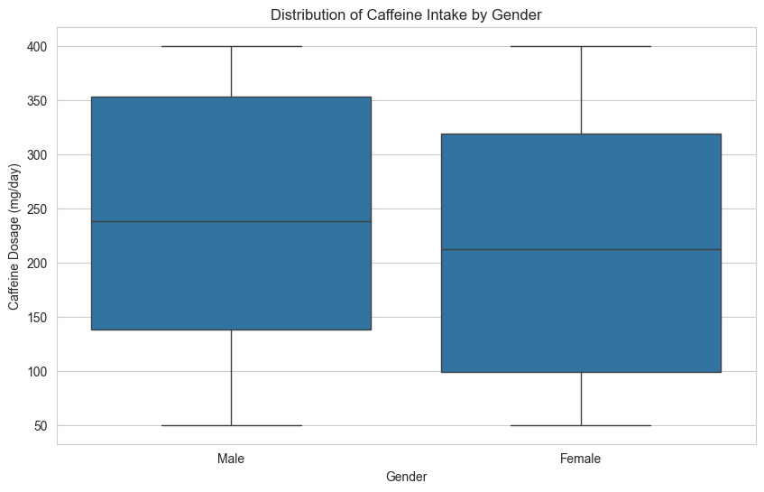

| gender | 25% | 50% | 75% | IQR | Lower Whisker | Upper Whisker |
| --- | --- | --- | --- | --- | --- | --- |
| Female | 99.0 | 212.0 | 319.0 | 220.0 | -231.0 | 649.0 |
| Male | 138.0 | 238.0 | 353.0 | 215.0 | -184.5 | 675.5 |

```python
import matplotlib.pyplot as plt
import seaborn as sns

# Set the style
sns.set_style("whitegrid")

# Create a boxplot for caffeine intake distribution by gender
plt.figure(figsize=(10, 6))
sns.boxplot(x='gender', y='caffeine_dosage_mg', data=df_study_based)
plt.title('Distribution of Caffeine Intake by Gender')
plt.xlabel('Gender')
plt.ylabel('Caffeine Dosage (mg/day)')
plt.show()


# Calculate the statistics for the boxplot
boxplot_stats = df_study_based.groupby("gender")["caffeine_dosage_mg"].describe(percentiles=[.25, .5, .75])

# Calculate IQR, lower whisker, and upper whisker
boxplot_stats["IQR"] = boxplot_stats["75%"] - boxplot_stats["25%"]
boxplot_stats["Lower Whisker"] = boxplot_stats["25%"] - 1.5 * boxplot_stats["IQR"]
boxplot_stats["Upper Whisker"] = boxplot_stats["75%"] + 1.5 * boxplot_stats["IQR"]

# Select relevant columns
boxplot_stats = boxplot_stats[["25%", "50%", "75%", "IQR", "Lower Whisker", "Upper Whisker"]]

boxplot_stats
```

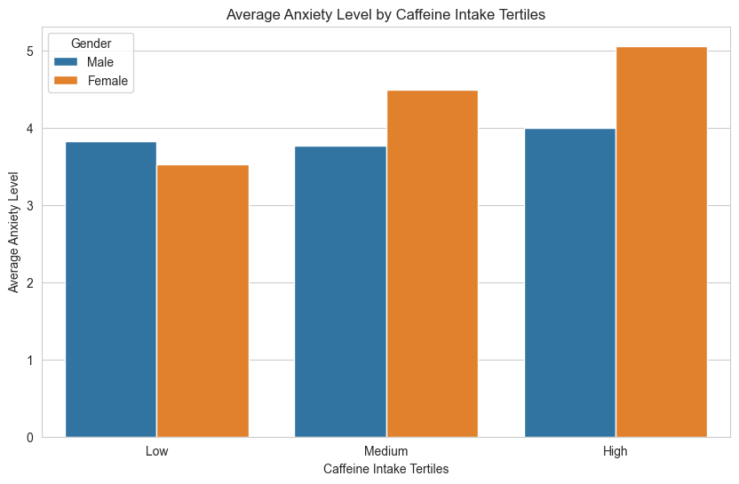

| gender caffeine_tertile | Female | Male |
| --- | --- | --- |
| Low | 3.526718 | 3.827397 |
| Medium | 4.493827 | 3.766667 |
| High | 5.059130 | 3.996078 |

```python
# Create caffeine intake tertiles
df_study_based['caffeine_tertile'] = pd.qcut(df_study_based['caffeine_dosage_mg'], q=3, labels=['Low', 'Medium', 'High'])

# Create a barplot for average anxiety levels by caffeine intake tertiles
plt.figure(figsize=(10, 6))
sns.barplot(x='caffeine_tertile', y='anxiety_level', hue='gender', data=df_study_based, errorbar=None)
plt.title('Average Anxiety Level by Caffeine Intake Tertiles')
plt.xlabel('Caffeine Intake Tertiles')
plt.ylabel('Average Anxiety Level')
plt.legend(title='Gender')
plt.show()

# Group by 'caffeine_tertile' and 'gender' and calculate the average anxiety levels
caffeine_tertile_summary = df_study_based.groupby(['caffeine_tertile', 'gender'])['anxiety_level'].mean().unstack()

caffeine_tertile_summary
```

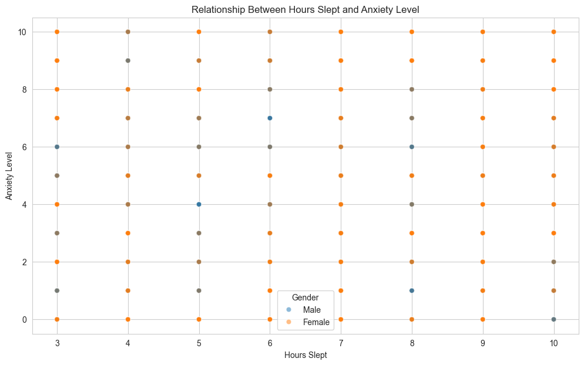

| gender hours_slept | Female | Male |
| --- | --- | --- |
| 3 | 4.273118 | 4.081481 |
| 4 | 3.710417 | 3.920000 |
| 5 | 4.485437 | 4.368421 |
| 6 | 4.319048 | 4.131579 |
| 7 | 4.876289 | 3.231250 |
| 8 | 4.171429 | 3.160000 |
| 9 | 4.173333 | 4.543750 |
| 10 | 4.541053 | 3.393939 |

```python
# Create a scatter plot for relationship between hours slept and anxiety levels
plt.figure(figsize=(12, 7))
sns.scatterplot(x='hours_slept', y='anxiety_level', hue='gender', data=df_study_based, alpha=0.5)
plt.title('Relationship Between Hours Slept and Anxiety Level')
plt.xlabel('Hours Slept')
plt.ylabel('Anxiety Level')
plt.legend(title='Gender')
plt.show()

# Calculate the average anxiety level for each hour of sleep, grouped by gender
avg_anxiety_by_sleep = df_study_based.groupby(['hours_slept', 'gender'])['anxiety_level'].mean().unstack()

avg_anxiety_by_sleep
```

#### **Detailed Analysis of the Refined Mock Dataset**

### **Caffeine Consumption Insights**:

- The dataset reflects an average caffeine intake of approximately 220.31 mg.
- The range of caffeine consumption spans from a modest 50 mg to a substantial 400 mg.
- A closer look reveals that the median caffeine intake stands at 219.5 mg. Breaking it down further, 25% of the participants consumed less than 105 mg, whereas another 25% had an intake exceeding 331.25 mg.

### **Anxiety Metrics**:

- On the anxiety scale (ranging from 0 to 10), the average score hovers around 4.21.
- This scale captures anxiety levels as low as 0 and as high as 10.
- Delving deeper, the median anxiety score is situated at 4, with the lower and upper quartiles positioned at 2 and 6, respectively.

### **Sleep Duration Analysis**:

- On average, participants reported sleeping for about 6.46 hours.
- The spectrum of sleep duration extends from a minimum of 3 hours to a maximum of 10 hours.
- A detailed breakdown reveals that half of the participants reported sleeping for 6 hours or less. A quarter of them slept for 4 hours or less, while the remaining quarter enjoyed more than 8.25 hours of rest.

### **Demographic Distribution**:

- **Gender**: The dataset predominantly consists of female data points, accounting for 73.5%. Males represent the remaining 26.5%.
- **Age Group**: The age distribution is relatively balanced:
  - 46-55 years: 21.1%
  - 18-25 years: 20.6%
  - 56+ years: 20.1%
  - 36-45 years: 19.7%
  - 26-35 years: 18.5%

### **Visual Analysis: Caffeine Intake Distribution**:

- **Females**:
  - Median Intake: 212 mg
  - Quartile Distribution: Q1 at 99 mg, Q3 at 319 mg
  - IQR: 220 mg
  - Whiskers: Lower at -231 mg (indicative of no extreme low values), Upper at 649 mg
- **Males**:
  - Median Intake: 238 mg
  - Quartile Distribution: Q1 at 138 mg, Q3 at 353 mg
  - IQR: 215 mg
  - Whiskers: Lower at -184.5 mg (suggestive of no extreme low outliers), Upper at 675.5 mg

### **Visual Analysis: Anxiety Levels by Caffeine Intake**:

- **Females**:
  - Low Tertile: 3.53
  - Medium Tertile: 4.49
  - High Tertile: 5.06
- **Males**:
  - Low Tertile: 3.83
  - Medium Tertile: 3.77
  - High Tertile: 4.00

### **Visual Analysis: Sleep vs. Anxiety**:

A deeper dive into the relationship between sleep duration and anxiety levels reveals:

- **Females**:
  - 3h: 4.27, 4h: 3.71, 5h: 4.49, 6h: 4.32, 7h: 4.88, 8h: 4.17, 9h: 4.17, 10h: 4.54
- **Males**:
  - 3h: 4.08, 4h: 3.92, 5h: 4.37, 6h: 4.13, 7h: 3.23, 8h: 3.16, 9h: 4.54, 10h: 3.39

## Statistical testing:

1. **T-Test for Caffeine Intake by Gender**: To determine if the difference in caffeine intake between males and females is statistically significant.
2. **ANOVA for Anxiety Levels by Caffeine Tertiles**: This will help us determine if the mean anxiety levels are significantly different across the caffeine intake tertiles.
3. **Correlation Test**: To test the strength and direction of the linear relationship between hours slept and anxiety levels.

```python
from scipy.stats import ttest_ind

# Separate the data by gender
male_caffeine = df_study_based[df_study_based['gender'] == 'Male']['caffeine_dosage_mg']
female_caffeine = df_study_based[df_study_based['gender'] == 'Female']['caffeine_dosage_mg']

# Conduct the t-test
t_stat, p_value = ttest_ind(male_caffeine, female_caffeine)

t_stat, p_value
```

```
(5.845316392934217, 5.376752106342462e-09)
```

### 1. **T-Test: Caffeine Intake by Gender**

- **T-Statistic (t)**: The result, t = $5.8453$, suggests males tend to have a higher caffeine intake than females.
- **P-Value (p)**: The extremely low p-value, p = $5.38 \times 10^{-9}$, confirms the difference in caffeine intake between genders is statistically significant.

```python
import statsmodels.api as sm
from statsmodels.formula.api import ols

# Conducting ANOVA for Anxiety Levels by Caffeine Tertiles
anova_model = ols('anxiety_level ~ caffeine_tertile', data=df_study_based).fit()
anova_table = sm.stats.anova_lm(anova_model, typ=2)

anova_table
```

|  | sum_sq | df | F | PR(>F) |
| --- | --- | --- | --- | --- |
| caffeine_tertile | 1105.062884 | 2.0 | 68.894813 | 3.051095e-30 |
| Residual | 40075.580316 | 4997.0 | NaN | NaN |

### **2. ANOVA: Anxiety Levels by Caffeine Tertiles**

- **Sum of Squares**:
  - **Between Groups**: $1105.06$
  - **Within Groups**: $40075.58$
- **F-Statistic (F)**: The value, F = 68.89, indicates significant differences between group means.
- **P-Value**: The p-value, p = $3.05 \times 10^{-30}$, further confirms the observed differences in anxiety levels among the caffeine tertiles are statistically significant.

```python
from scipy.stats import pearsonr

# Conduct the correlation test
correlation_coefficient, p_value_corr = pearsonr(df_study_based['hours_slept'], df_study_based['anxiety_level'])

correlation_coefficient, p_value_corr
```

```
(0.012367734765776975, 0.3819300234509259)
```

### 3. **Pearson's Correlation Coefficient for Relationship between Hours Slept and Anxiety Level**

The Pearson's correlation coefficient measures the linear relationship between two datasets. Its value can range from -1 to 1:

- **-1**: Perfect negative linear relationship
- **0**: No linear relationship
- **1**: Perfect positive linear relationship

### **Correlation Coefficient (r)**:

The calculated correlation coefficient between hours slept and anxiety level is r≈$0.0124$. This value is very close to 0, suggesting a very weak positive linear relationship between the two variables. In other words, as the number of hours slept increases, the anxiety level slightly increases, but this relationship is very weak.

### **P-Value**:

The p-value associated with this correlation is p≈$0.382$. Typically, a p-value less than 0.05 (5% significance level) is considered evidence that the correlation is statistically significant. Since our p-value is greater than 0.05, we fail to reject the null hypothesis, suggesting that the correlation between hours slept and anxiety level in our sample might have arisen by random chance.

### **Conclusive Insights**:

1. Males, on average, consume more caffeine than females, and this difference is statistically significant.
2. Anxiety levels do vary based on caffeine intake tertiles, and this variation is statistically significant.
3. Although there's a slight positive relationship between hours slept and anxiety levels, it's not statistically significant.